# Tutorial on statistical power analysis via simulations in R

Andrey Chetverikov

January 28, 2020

```r
# this chunk loads the libraries and sets up ggplot theme
library(apastats)
library(ggplot2)
library(data.table)
library(Hmisc)
library(patchwork)
library(MASS)
library(knitr)
library(ez)
library(pwr)

# packages from github
library(apastats) # devtools::install_github('achetverikov/apastats',subdir='apastats')
library(patchwork) # devtools::install_github("thomasp85/patchwork")
library(Superpower) # devtools::install_github("arcaldwell49/Superpower")

default_font <- 'sans'
default_font_size <- 12
default_font_size_mm <- default_font_size/ggplot2:::.pt

default_theme<-theme_light(base_size = default_font_size, base_family = default_font)+theme(
  axis.line=element_line(size=I(0.5)),
  axis.ticks= element_line(size=I(0.25), colour = 'gray'),
  axis.line.x=element_line(),
  axis.line.y=element_line(),
  panel.grid=element_line(colour = 'gray',size = I(0.5)),
  panel.grid.minor = element_blank(),
  legend.title=element_text(size=rel(1)),
  strip.text=element_text(size=rel(1), color = 'black'),
  axis.text=element_text(size=rel(0.9)),
  axis.title=element_text(size=rel(1)),
  panel.border= element_blank(),
  strip.background = element_blank(),
  legend.position   ='right',
  plot.title=element_text(size=rel(1), hjust = 0.5),
  text=element_text(size=default_font_size),
  legend.text=element_text(size=rel(1)),
  axis.line.x.bottom = element_blank(),
  axis.line.y.left = element_blank())
theme_set(default_theme)

opts_chunk$set(cache = T)


# n_reps sets the simulation N
max_n_reps = 1000
```

This notebooks aims to demonstrate how to do simulations in R to estimate required sample size and number of trials. First, I’ll show how to do simulations for a simple t-test or ANOVA using means and SDs often reported in papers. Then, I’ll show how to obtain power estimates by estimating the parameters of within-subject design from existing data and then using it to simulate new datasets.

# Simulating data for the one-sample t-test

Let’s start with a very simple example. Say, you want to know how many subjects are needed to test a hypothesis that some parameter value (for example, bias in an orientation estimation task) is different from zero with a simple t-test. Here, your data model is that in the population you have a normal distribution of biases with a certain mean and standard deviation.

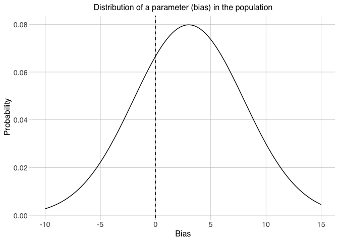

```r
set.seed(512)

mu = 3
sigma = 5
n = 20

p <- ggplot(data.frame(x = seq(-10, 15)), aes(x = x))+
  stat_function(fun = dnorm, args = list(mean = mu, sd = sigma))+
  geom_vline(xintercept = 0, linetype = 2)+
  labs(x = 'Bias', y = 'Probability', title = 'Distribution of a parameter (bias) in the population')

p
```

How many subjects do you need to make sure that you will find your effect if the population is what you assume it is? For example, what if you collect data from 10 participants?

```r
# generate the sample
sample_data <- rnorm(10, mean = mu, sd = sigma)

# get mean and sd
smean.sd(sample_data)
```

```
##     Mean       SD
## 2.975088 4.911560
```

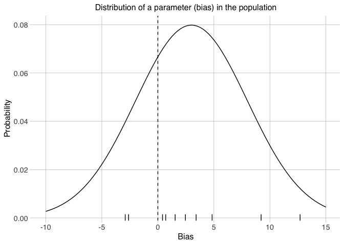

```r
# plot them together with the population distribution
p + geom_rug(data = data.frame(x = sample_data))
```

```r
# compute t-value and degrees of freedom
t_value <- (mean(sample_data))/(sd(sample_data)/sqrt(length(sample_data)))
df <- length(sample_data)-1

# compute p-value
round.p(2*pt(abs(t_value), df, lower=F))
```

```
## [1] "= .088"
```

For this sample, the effect is not significant. But of course, no one can guarantee that you will get exactly this sample. What you are interested in is the average probability of getting a significant result from your data, also called the “power” of your test.

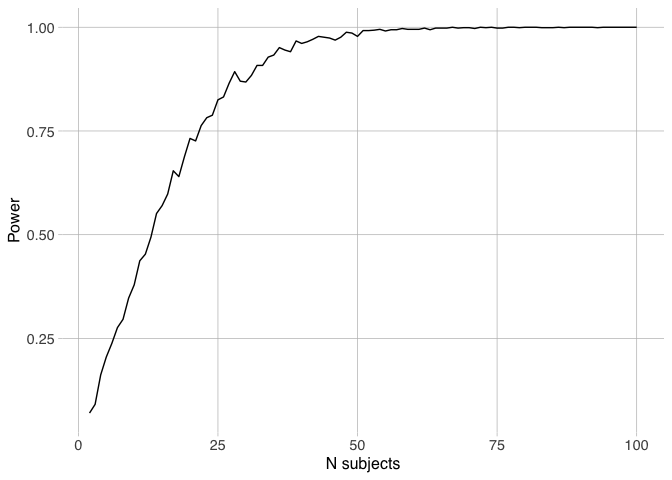

```r
# create a "simulation grid" defining the values for the number of subjects you want to see the power for and the number of replications over which you will aggregate

sim_dt <- data.table(expand.grid(n_subjects = 2:100, n_reps = 1:max_n_reps))

# for each replication and each number of subjects, create the sample and compute its mean and SD
# rnorm(...) generates the data for n_subjects
# data.frame(t(...)) transforms the vector output of smean.sd to a one-row data.frame that is easy to combine for data.table
sim_dt <- sim_dt[, data.frame(t(smean.sd(rnorm(n_subjects, mean = mu, sd = sigma)))), by = .(n_subjects, n_reps)]

# then get the t and p like it was done above
sim_dt[, t_value := (Mean)/(SD/sqrt(n_subjects))]
sim_dt[, p_val := 2*pt(abs(t_value), n_subjects-1, lower=F)]

# compute the average probability of getting a significant result
sim_dt_avg<-sim_dt[,.(power = mean(as.numeric(p_val<0.05))), by = n_subjects]

# plot power as a function of the number of subjects
p_power <- ggplot(sim_dt_avg, aes(x = n_subjects, y = power))+
  geom_line(stat='summary', fun.y = mean)+
  labs(y = 'Power', x = 'N subjects')

p_power
```

By convention, people often want to know the number of participants to achieve 80% power. Here, in this example, 25 subjects are going to be enough.

```r
sim_dt_avg[power>=0.8, min(n_subjects)] # minimal number of subjects needed to achieve 80% power
```

```
## [1] 25
```

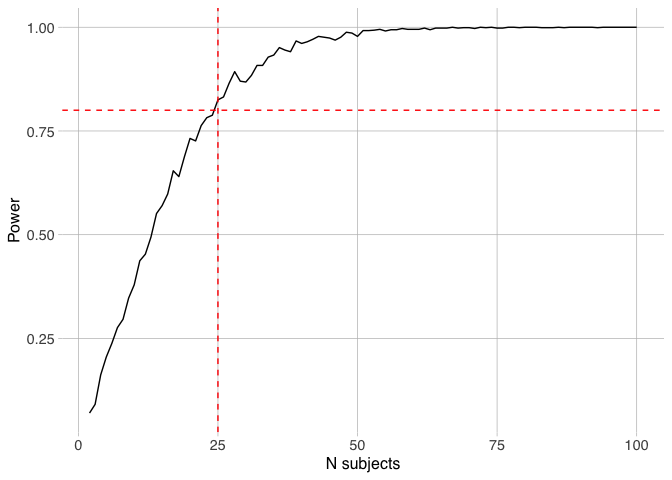

```r
p_power + geom_hline(yintercept = 0.8, linetype = 2, color = 'red') + geom_vline(xintercept = sim_dt_avg[power>=0.8, min(n_subjects)], linetype = 2, color = 'red')
```

> Exercise 1: Simulate and compare the power curves and estimate minimal *N* for $\sigma = 15$ and $\sigma = 3$.

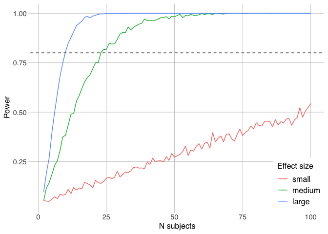

```r
# we are going to check three effect sizes, "small", "medium" and "large"
es_values <- c(0.2, 0.6, 1)

# assuming the same mean (mu = 3), we can get the sigmas for these levels of effect sizes
sigma_values <- mu/es_values

# create a new simulation grid this time varying sigma (SD) of the population distribution
sim_dt <- data.table(expand.grid(n_subjects = 2:100, n_reps = 1:max_n_reps, sigma = sigma_values))

# repeat the power calculations, but this time for different sigma
sim_dt <- sim_dt[, data.frame(t(smean.sd(rnorm(n_subjects, mean = mu, sd = sigma)))), by = .(n_subjects, n_reps, sigma)]

# then get the t and p
sim_dt[, t_value := (Mean)/(SD/sqrt(n_subjects))]
sim_dt[, p_val:=2*pt(abs(t_value), n_subjects-1, lower=F)]

# compute the average probability of getting a significant result
sim_dt_avg<-sim_dt[,.(power = mean(as.numeric(p_val<0.05))), by = .(n_subjects, sigma)]

sim_dt_avg[,es_labels := factor(mu/sigma, labels = c('small','medium','large'))]
# plot power as a function of the number of subjects
p_power <- ggplot(sim_dt_avg, aes(x = n_subjects, y = power, color = es_labels))+
  geom_line(stat='summary', fun.y = mean)+
  labs(y = 'Power', x = 'N subjects', color = 'Effect size')+
  theme(legend.position = c(1,0), legend.justification = c(1,0))+
  geom_hline(yintercept = 0.8, linetype = 2, color = 'black')

p_power
```

```r
# get the minimal number of subjects needed to achieve 80% power
sim_dt_avg[power>=0.8, min(n_subjects), by = .(es_labels)]
```

| es_labels | V1 |
| --- | --- |
| medium | 23 |
| large | 10 |

```r
# compare with the results from stats::power.t.test
sapply(sigma_values, function(x) power.t.test(delta = mu, sd = x, power = 0.8, type = 'one.sample' ))
```

```
##             [,1]
## n           198.1513
## delta       3
## sd          15
## sig.level   0.05
## power       0.8
## alternative "two.sided"
## note        NULL
## method      "One-sample t test power calculation"
##             [,2]
## n           23.79457
## delta       3
## sd          5
## sig.level   0.05
## power       0.8
## alternative "two.sided"
## note        NULL
## method      "One-sample t test power calculation"
##             [,3]
## n           9.937864
## delta       3
## sd          3
## sig.level   0.05
## power       0.8
## alternative "two.sided"
## note        NULL
## method      "One-sample t test power calculation"
```

For a small effect size even one hundred subjects is not enough!

# ANOVA

The same logic can be applied to any other test. Let’s do it for a between-subject ANOVA just for practice. Say, we have three equally-sized groups with different means and SDs. What is the sample size needed?

```r
group_labels <- c('A','B','C')
means <- c(0, 0.5, 1)
sds <- c(1, 2, 3)

conditions <- data.table(label = group_labels, mu = means, sigma = sds)

# lets try to run ANOVA with N = 20 per group
n_subjects <- 20

# generate the data
data <- conditions[,.( dv = rnorm(n_subjects, mu, sigma)), by = .(label)]
# compute ANOVA
aov_res <- aov(dv~label, conditions[,.( dv = rnorm(n_subjects, mu, sigma)), by = .(label)])
aov_summary <- summary(aov_res)

# for the power simulations, we need to extract p-value. How to do this?
# it's useful to look at the structure of the summary using the str function
str(aov_summary)
```

```
## List of 1
##  $ :Classes 'anova' and 'data.frame':    2 obs. of  5 variables:
##   ..$ Df     : num [1:2] 2 57
##   ..$ Sum Sq : num [1:2] 32.3 345.8
##   ..$ Mean Sq: num [1:2] 16.14 6.07
##   ..$ F value: num [1:2] 2.66 NA
##   ..$ Pr(>F) : num [1:2] 0.0786 NA
##  - attr(*, "class")= chr [1:2] "summary.aov" "listof"
```

```r
# we see that it's a list of length 1 with a data.frame inside
# so to get p_value we first extract the data.frame from a list and then take the first value from `Pr(>F)` column (if this sounds complicated, try to see just the extracted data.frame)
aov_summary[[1]]$`Pr(>F)`[1]
```

```
## [1] 0.07858322
```

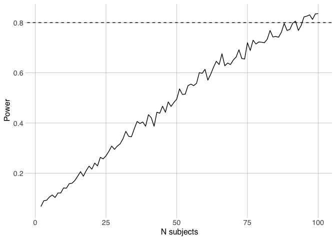

```r
# now, we'll wrap this code in a function for the power calculations
get_sim_anova_p <- function(n_subjects, conditions){
  aov_res <- aov(dv~label, conditions[,.( dv = rnorm(n_subjects, mu, sigma)), by = .(label)])
  summary(aov_res)[[1]]$`Pr(>F)`[1]
}

# create a new simulation grid (the group parameters are fixed, and the n_subjects here is the number of subjects per group)
sim_dt <- data.table(expand.grid(n_subjects = 2:100, n_reps = 1:max_n_reps))

sim_dt <- sim_dt[, p_val:=get_sim_anova_p(n_subjects, conditions ), by = .(n_subjects, n_reps)]

# compute the average probability of getting a significant result
sim_dt_avg<-sim_dt[,.(power = mean(as.numeric(p_val<0.05))), by = .(n_subjects)]

# plot power as a function of the number of subjects
p_power <- ggplot(sim_dt_avg, aes(x = n_subjects, y = power))+
  geom_line(stat='summary', fun.y = mean)+
  labs(y = 'Power', x = 'N subjects')+
  theme(legend.position = c(1,0), legend.justification = c(1,0))+
  geom_hline(yintercept = 0.8, linetype = 2, color = 'black')

p_power
```

```r
# get the minimal number of subjects needed to achieve 80% power
sim_dt_avg[power>=0.8, min(n_subjects)]
```

```
## [1] 92
```

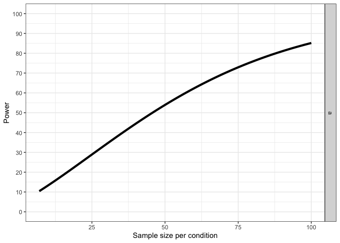

```r
# compare with the results from Superpower
anovapower_res <- plot_power((ANOVA_design('3b', 30, means, sds)), alpha_level = 0.05, min_n = 7, max_n = 100, plot = TRUE)
```

```r
anovapower_res$power_df[anovapower_res$power_df$a>=80,][1,]
```

|  | n | a |
| --- | --- | --- |
| 82 | 88 | 80.03808 |

> Exercise 2: Simulate and compare the power curves and estimate minimal N for a two-sample t-test with $\mu = 5$, $\sigma = 10$ and $\mu = 15$, $\sigma = 10$.

```r
group_labels <- c('A','B')
means <- c(5, 15)
sds <- c(10, 10)

conditions <- data.table(label = group_labels, mu = means, sigma = sds)

# how to get p-value from t-test? check the structure of t-test object
str(t.test(rnorm(5000)))
```

```
## List of 9
##  $ statistic  : Named num 0.511
##   ..- attr(*, "names")= chr "t"
##  $ parameter  : Named num 4999
##   ..- attr(*, "names")= chr "df"
##  $ p.value    : num 0.609
##  $ conf.int   : num [1:2] -0.0207 0.0353
##   ..- attr(*, "conf.level")= num 0.95
##  $ estimate   : Named num 0.00731
##   ..- attr(*, "names")= chr "mean of x"
##  $ null.value : Named num 0
##   ..- attr(*, "names")= chr "mean"
##  $ alternative: chr "two.sided"
##  $ method     : chr "One Sample t-test"
##  $ data.name  : chr "rnorm(5000)"
##  - attr(*, "class")= chr "htest"
```

```r
t.test(rnorm(5000))$p.value
```

```
## [1] 0.6356334
```

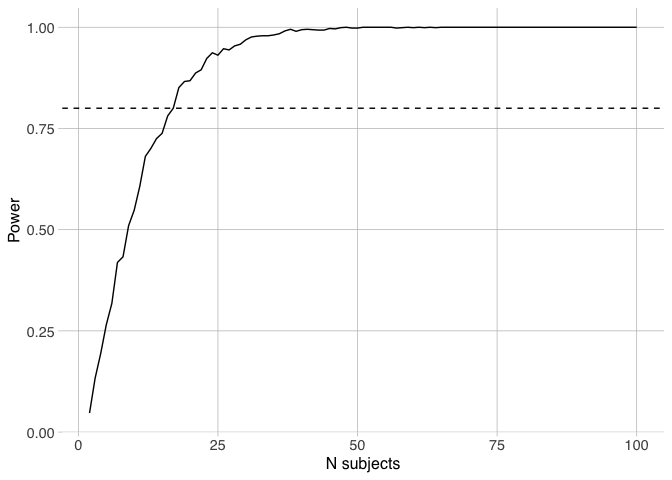

```r
# now, we'll wrap this code in a function for the power calculations
get_sim_ttest_p <- function(n_subjects, conditions){
  t_res <- t.test(dv~label, conditions[,.( dv = rnorm(n_subjects, mu, sigma)), by = .(label)])
  t_res$p.value
}

# create a new simulation grid (the group parameters are fixed, and the n_subjects here is the number of subjects per group)
sim_dt <- data.table(expand.grid(n_subjects = 2:100, n_reps = 1:max_n_reps))

sim_dt <- sim_dt[, p_val:=get_sim_ttest_p(n_subjects, conditions ), by = .(n_subjects, n_reps)]

# compute the average probability of getting a significant result
sim_dt_avg<-sim_dt[,.(power = mean(as.numeric(p_val<0.05))), by = .(n_subjects)]

# plot power as a function of the number of subjects
p_power <- ggplot(sim_dt_avg, aes(x = n_subjects, y = power))+
  geom_line(stat='summary', fun.y = mean)+
  labs(y = 'Power', x = 'N subjects')+
  theme(legend.position = c(1,0), legend.justification = c(1,0))+
  geom_hline(yintercept = 0.8, linetype = 2, color = 'black')

p_power
```

```r
# get the minimal number of subjects needed to achieve 80% power
sim_dt_avg[power>=0.8, min(n_subjects)]
```

```
## [1] 17
```

```r
# compare with the results from pwr::pwr.t.test
pwr.t.test(d = (means[2]-means[1])/sqrt(sum(sds^2)/2), power = 0.8, type = 'two.sample' )
```

```
##
##      Two-sample t test power calculation
##
##               n = 16.71472
##               d = 1
##       sig.level = 0.05
##           power = 0.8
##     alternative = two.sided
##
## NOTE: n is number in *each* group
```

For simple designs, it is easy to estimate power from summary statistics (e.g., means and variances by group) reported in previous papers. On the other hand, for more complex designs this is not always the case.